# HelmNet_Version_1

## Problem Statement

### Business Context

Workplace safety is very important in places like construction sites, factories, and industrial areas. Workers are required to wear safety helmets to protect themselves from head injuries caused by falling objects, machines, or accidents.

However, in large workplaces, it is difficult to manually check whether every worker is wearing a helmet. Manual monitoring can take a lot of time and may also lead to mistakes.

To solve this problem, SafeGuard Corp wants to build an automated image classification system that can detect whether a worker is wearing a safety helmet or not. This system will help improve safety monitoring, reduce accidents, and ensure workers follow safety rules properly.

### Objective

As a data scientist at SafeGuard Corp, the main objective of this project is to develop an image classification model that can classify worker images into two categories:

With Helmet – Images of workers wearing safety helmets.

Without Helmet – Images of workers not wearing safety helmets.

The model should automatically identify helmet usage from images and help improve workplace safety.

### Data Description

**Data Dictionary**

The dataset contains a total of 4125 images divided into two classes:

1. With Helmet: 3161 images
2. Without Helmet: 964 images

**Dataset Characteristics**

Variations in Conditions: The images are collected from different environments such as construction sites, factories, and industrial areas. The dataset includes variations in:

- Lighting conditions
- Camera angles
- Backgrounds
- Worker postures

These variations help the model learn real-world scenarios more effectively.

Worker Activities: Workers in the images are performing different activities such as:

- Standing
- Walking
- Using tools
- Working on machines

This helps the model become more robust and accurate for practical applications.

## Installing and importing the necessary libraries

```python
!pip install tensorflow[and-cuda] scikit-learn==1.6.1 opencv-python==4.12.0.88 seaborn==0.13.2 matplotlib==3.10.0 numpy==2.0.2 pandas==2.2.2 -q
```

```
   ━━━━━━━━━━━━━━━━━━━━━━━━━━━━━━━━━━━━━━━━ 67.0/67.0 MB 12.7 MB/s eta 0:00:00
```

```python
import os
import random
import numpy as np   # Importing numpy for Matrix Operations
import pandas as pd
import seaborn as sns
import matplotlib.image as mpimg       # Importing pandas to read CSV files
import matplotlib.pyplot as plt        # Importting matplotlib for Plotting and visualizing images
import math                            # Importing math module to perform mathematical operations
import cv2


# Tensorflow modules

import keras
import tensorflow as tf
from tensorflow.keras.preprocessing.image import ImageDataGenerator     # Importing the ImageDataGenerator for data augmentation
from tensorflow.keras.models import Sequential       # Importing the sequential module to define a sequential model
from tensorflow.keras.layers import Dense,Dropout,Flatten,Conv2D,MaxPooling2D,BatchNormalization # Defining all the layers to build our CNN Model
from tensorflow.keras.optimizers import Adam,SGD     # Importing the optimizers which can be used in our model
from sklearn import preprocessing   # Importing the preprocessing module to preprocess the data
from sklearn.model_selection import train_test_split  # Importing train_test_split function to split the data into train and test
from tensorflow.keras.models import Model
from keras.applications.vgg16 import VGG16    # Importing confusion_matrix to plot the confusion matrix

# Display images using OpenCV
from google.colab.patches import cv2_imshow

#Imports functions for evaluating the performance of machine learning models
from sklearn.metrics import confusion_matrix, f1_score,accuracy_score, recall_score, precision_score, classification_report
from sklearn.metrics import mean_squared_error as mse # Importing cv2_imshow from google.patches to display images

# Ignore warnings
import warnings
warnings.filterwarnings('ignore')
```

### GPUs and Tensorflow version

```python
print("Num GPUs Available:", len(tf.config.list_physical_devices('GPU')))
print(tf.__version__)
```

```
Num GPUs Available: 1
2.20.0
```

### Setting Random Seed

```python
# 1. Set Python random seed
random.seed(812)

# 2. Set NumPy random seed
np.random.seed(812)

# 3. Set TensorFlow seed (covers Keras + backend)
tf.keras.utils.set_random_seed(812)

# 4. Enable deterministic GPU ops (if using GPU)
tf.config.experimental.enable_op_determinism()
```

### Loading Images

```python
from google.colab import files

uploaded = files.upload()
```

Upload widget is only available when the cell has been executed in the current browser session. Please rerun this cell to enable.

```
Saving images (1).npy to images (1).npy
```

#### Checking File size

```python
import os

size = os.path.getsize('/content/images (1).npy')

print("File Size in MB:", size / (1024 * 1024))
```

```
File Size in MB: 472.06890869140625
```

#### Checking the shape of Image

```python
images = np.load('/content/images (1).npy')

print(images.shape)
```

```
(4125, 200, 200, 3)
```

Observation:

The dataset contains 4125 images with dimensions 200 × 200 × 3, where 200 × 200 represents the image size and 3 represents RGB color channels. The uniform image dimensions make the dataset suitable for CNN-based image classification.

### Reading Labels

```python
labels = pd.read_csv('/content/labels.csv')

labels.sample(10)
```

|  | label |
| --- | --- |
| 2736 | 1 |
| 2742 | 1 |
| 1429 | 1 |
| 3622 | 1 |
| 1579 | 1 |
| 3584 | 1 |
| 4002 | 1 |
| 428 | 0 |
| 1432 | 1 |
| 543 | 0 |

Observations:

Table shows two categores : 1- With helmet and 0- without helmet

### Checking First Image

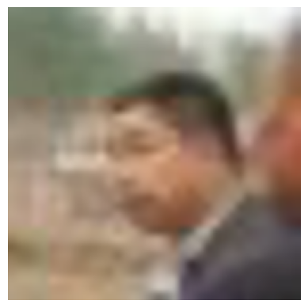

```python
# Display first image
plt.imshow(images[0])
plt.axis('off')
plt.show()
```

Observation:

Displaying first image indicates a picture without helmet with unclear appearance.

### Plotting Random Images from Each Class and Printing Labels

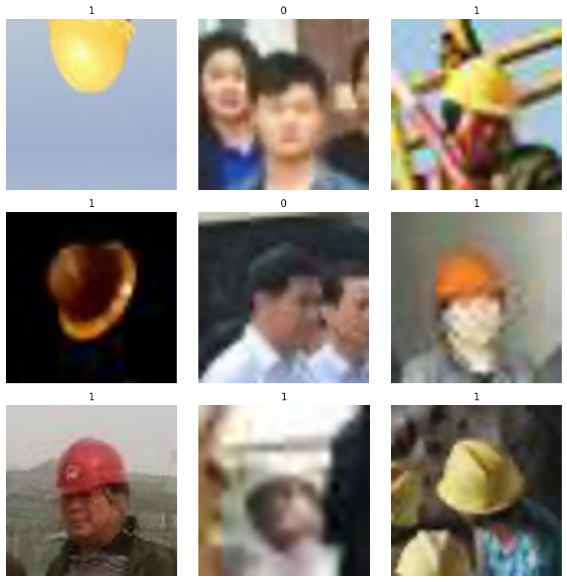

```python
import random

# Plot random images
plt.figure(figsize=(10,10))

for i in range(9):

    index = random.randint(0, len(images)-1)

    plt.subplot(3,3,i+1)
    plt.imshow(images[index])

    # Display label
    plt.title(labels.iloc[index][0])

    plt.axis('off')

plt.tight_layout()
plt.show()
```

#### Checking data Imbalance

```python
# Count labels
class_counts = labels.iloc[:,0].value_counts()

print(class_counts)
```

```
label
1    3161
0     964
Name: count, dtype: int64
```

### Key Observations from EDA

1. The dataset contains two classes: 0 → Without Helmet 1 → With Helmet
2. The dataset is imbalanced because the number of helmet images is higher than non-helmet images.
3. Total number of images is 4125 and images have shape: 200 × 200 × 3
4. The dataset contains variations in lighting conditions, backgrounds, and viewing angles.
5. Random image visualization shows clear visual differences between helmet and non-helmet classes.
6. Despite class imbalance, the dataset is suitable for classification, and imbalance can be handled using techniques such as class weights or data augmentation during model training.

#### Balancing the dataset

```python
from sklearn.utils import resample

# Create dataframe
df = pd.DataFrame({'label': labels.iloc[:,0]})

# Add image indices
df['index'] = np.arange(len(images))

# Separate classes
class1 = df[df['label'] == 1]
class0 = df[df['label'] == 0]

# Oversample minority class
class0_new = resample(class0,
                      replace=True,
                      n_samples=len(class1),
                      random_state=42)

# Combine balanced data
balanced_df = pd.concat([class1, class0_new])

# Shuffle data
balanced_df = balanced_df.sample(frac=1, random_state=42)

# Get balanced images and labels
balanced_images = images[balanced_df['index']]
balanced_labels = balanced_df['label']

# Check shapes
print(balanced_images.shape)
print(balanced_labels.shape)
```

```
(6322, 200, 200, 3)
(6322,)
```

Observation:

The dataset is now balanced, with both classes containing 3161 images each. This helps improve fair learning and reduces model bias during classification.

```python
balanced_images = balanced_images[:1000]
balanced_labels = balanced_labels[:1000]
```

Taking a sample of 1000 images and 1000 lables from data due to crashing issue.

### Resizing the images

```python
import cv2
import numpy as np

# Resize images
resized_images = np.array([
    cv2.resize(img, (32,32))
    for img in balanced_images
], dtype=np.float32)

print(resized_images.shape)
```

```
(1000, 32, 32, 3)
```

Note: My Colab is crashing because the notebook is exhausting RAM during CNN training. This prevented me to run my codes. The main reasons are:

1. large dataset (6322 images after balancing),
2. image size,
3. VGG/CNN memory usage,
4. loading all images into RAM at once, and training with large batches So i decided to go with smaller portion of this dataset, resizing images to 32 x 32, small batches and training with safe settings.

### Splitting Data Into Training and Testing

```python
from sklearn.model_selection import train_test_split

X_train, X_temp, y_train, y_temp = train_test_split(
    resized_images,
    balanced_labels,
    test_size=0.3,
    random_state=42
)

X_val, X_test, y_val, y_test = train_test_split(
    X_temp,
    y_temp,
    test_size=0.5,
    random_state=42
)
# Print shapes
print("Training Data :", X_train.shape)
print("Validation Data :", X_val.shape)
print("Testing Data :", X_test.shape)
```

```
Training Data : (700, 32, 32, 3)
Validation Data : (150, 32, 32, 3)
Testing Data : (150, 32, 32, 3)
```

#### Applying Normalization

```python
# Normalize images
X_train = X_train / 255.0
X_val = X_val / 255.0
X_test = X_test / 255.0

# Check pixel range
print(X_train.min(), X_train.max())
```

```
0.0 1.0
```

Observation:

Normalization scaled the image pixel values between 0 and 1, which helps improve CNN model performance and training stability.

### Convolutional Neural Network (CNN) from Scratch

Defining the CNN Model

```python
model = Sequential()

model.add(Conv2D(16, (3,3),
                 activation='relu',
                 input_shape=(32,32,3)))

model.add(MaxPooling2D(2,2))

model.add(Conv2D(32, (3,3), activation='relu'))

model.add(MaxPooling2D(2,2))

model.add(Flatten())

model.add(Dense(64, activation='relu'))

model.add(Dense(1, activation='sigmoid'))

model.summary()
```

```
Model: "sequential_2"
```

```
┏━━━━━━━━━━━━━━━━━━━━━━━━━━━━━━━━━┳━━━━━━━━━━━━━━━━━━━━━━━━┳━━━━━━━━━━━━━━━┓
┃ Layer (type)                    ┃ Output Shape           ┃       Param # ┃
┡━━━━━━━━━━━━━━━━━━━━━━━━━━━━━━━━━╇━━━━━━━━━━━━━━━━━━━━━━━━╇━━━━━━━━━━━━━━━┩
│ conv2d_4 (Conv2D)               │ (None, 30, 30, 16)     │           448 │
├─────────────────────────────────┼────────────────────────┼───────────────┤
│ max_pooling2d_4 (MaxPooling2D)  │ (None, 15, 15, 16)     │             0 │
├─────────────────────────────────┼────────────────────────┼───────────────┤
│ conv2d_5 (Conv2D)               │ (None, 13, 13, 32)     │         4,640 │
├─────────────────────────────────┼────────────────────────┼───────────────┤
│ max_pooling2d_5 (MaxPooling2D)  │ (None, 6, 6, 32)       │             0 │
├─────────────────────────────────┼────────────────────────┼───────────────┤
│ flatten_2 (Flatten)             │ (None, 1152)           │             0 │
├─────────────────────────────────┼────────────────────────┼───────────────┤
│ dense_4 (Dense)                 │ (None, 64)             │        73,792 │
├─────────────────────────────────┼────────────────────────┼───────────────┤
│ dense_5 (Dense)                 │ (None, 1)              │            65 │
└─────────────────────────────────┴────────────────────────┴───────────────┘
```

```
 Total params: 78,945 (308.38 KB)
```

```
 Trainable params: 78,945 (308.38 KB)
```

```
 Non-trainable params: 0 (0.00 B)
```

#### Model Configuration

```python
model.compile(
    optimizer='adam',
    loss='binary_crossentropy',
    metrics=['accuracy']
)

# Configuration
epochs = 10
batch_size = 5
```

#### Training the Model

```python
history = model.fit(
    X_train,
    y_train,
    validation_data=(X_val, y_val),
    epochs=epochs,
    batch_size=batch_size
)
```

```
140/140 ━━━━━━━━━━━━━━━━━━━━ 4s 11ms/step - accuracy: 0.7300 - loss: 0.5498 - val_accuracy: 0.8800 - val_loss: 0.3447
140/140 ━━━━━━━━━━━━━━━━━━━━ 3s 5ms/step - accuracy: 0.8414 - loss: 0.3774 - val_accuracy: 0.9000 - val_loss: 0.2893
140/140 ━━━━━━━━━━━━━━━━━━━━ 1s 6ms/step - accuracy: 0.8729 - loss: 0.3121 - val_accuracy: 0.9067 - val_loss: 0.2635
140/140 ━━━━━━━━━━━━━━━━━━━━ 1s 5ms/step - accuracy: 0.8829 - loss: 0.2609 - val_accuracy: 0.9133 - val_loss: 0.2650
140/140 ━━━━━━━━━━━━━━━━━━━━ 1s 5ms/step - accuracy: 0.9100 - loss: 0.2188 - val_accuracy: 0.9200 - val_loss: 0.2575
140/140 ━━━━━━━━━━━━━━━━━━━━ 1s 5ms/step - accuracy: 0.9300 - loss: 0.1850 - val_accuracy: 0.9267 - val_loss: 0.2838
140/140 ━━━━━━━━━━━━━━━━━━━━ 1s 5ms/step - accuracy: 0.9357 - loss: 0.1585 - val_accuracy: 0.9267 - val_loss: 0.3010
140/140 ━━━━━━━━━━━━━━━━━━━━ 1s 5ms/step - accuracy: 0.9429 - loss: 0.1420 - val_accuracy: 0.9200 - val_loss: 0.3139
140/140 ━━━━━━━━━━━━━━━━━━━━ 1s 5ms/step - accuracy: 0.9586 - loss: 0.1124 - val_accuracy: 0.9200 - val_loss: 0.3252
140/140 ━━━━━━━━━━━━━━━━━━━━ 1s 5ms/step - accuracy: 0.9686 - loss: 0.0827 - val_accuracy: 0.9333 - val_loss: 0.3680
```

#### Evaluatinig Model Performance

```python
# Evaluate Model

loss, accuracy = model.evaluate(X_test, y_test)

print("Test Accuracy :", accuracy)

print("Test Loss :", loss)

# Validation Accuracy and Loss

val_loss = history.history['val_loss'][-1]

val_accuracy = history.history['val_accuracy'][-1]

print("Validation Accuracy :", val_accuracy)

print("Validation Loss :", val_loss)
```

```
5/5 ━━━━━━━━━━━━━━━━━━━━ 0s 15ms/step - accuracy: 0.8800 - loss: 0.3810
Test Accuracy : 0.8799999952316284
Test Loss : 0.3809942901134491
Validation Accuracy : 0.9333333373069763
Validation Loss : 0.36802607774734497
```

#### Plotting Training Vs Validation

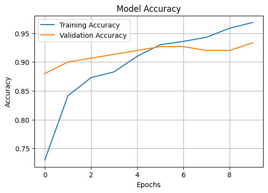

```python
plt.figure(figsize=(6,4))

plt.plot(history.history['accuracy'],
         label='Training Accuracy')

plt.plot(history.history['val_accuracy'],
         label='Validation Accuracy')

plt.title('Model Accuracy')

plt.xlabel('Epochs')

plt.ylabel('Accuracy')

plt.legend()

plt.grid(True)

plt.show()
```

Observation:

### Transfer Learning with VGG16 (Base)

#### Defining the Model

```python
# Load VGG16 base model
base_model = VGG16(
    weights='imagenet',
    include_top=False,
    input_shape=(32,32,3)
)

# Freeze base model layers
for layer in base_model.layers:
    layer.trainable = False

# Create model
model1 = Sequential()

model1.add(base_model)

model1.add(Flatten())

model1.add(Dense(64, activation='relu'))

model1.add(Dropout(0.5))

model1.add(Dense(1, activation='sigmoid'))

# Model summary
model1.summary()
```

```
Model: "sequential_4"
```

```
┏━━━━━━━━━━━━━━━━━━━━━━━━━━━━━━━━━┳━━━━━━━━━━━━━━━━━━━━━━━━┳━━━━━━━━━━━━━━━┓
┃ Layer (type)                    ┃ Output Shape           ┃       Param # ┃
┡━━━━━━━━━━━━━━━━━━━━━━━━━━━━━━━━━╇━━━━━━━━━━━━━━━━━━━━━━━━╇━━━━━━━━━━━━━━━┩
│ vgg16 (Functional)              │ (None, 1, 1, 512)      │    14,714,688 │
├─────────────────────────────────┼────────────────────────┼───────────────┤
│ flatten_4 (Flatten)             │ (None, 512)            │             0 │
├─────────────────────────────────┼────────────────────────┼───────────────┤
│ dense_8 (Dense)                 │ (None, 64)             │        32,832 │
├─────────────────────────────────┼────────────────────────┼───────────────┤
│ dropout_1 (Dropout)             │ (None, 64)             │             0 │
├─────────────────────────────────┼────────────────────────┼───────────────┤
│ dense_9 (Dense)                 │ (None, 1)              │            65 │
└─────────────────────────────────┴────────────────────────┴───────────────┘
```

```
 Total params: 14,747,585 (56.26 MB)
```

```
 Trainable params: 32,897 (128.50 KB)
```

```
 Non-trainable params: 14,714,688 (56.13 MB)
```

#### Defining Model Configuration

```python
model1.compile(
    optimizer=Adam(learning_rate=0.0001),
    loss='binary_crossentropy',
    metrics=['accuracy']
)

# Configuration
epochs = 10
batch_size = 5
```

#### Training the model

```python
history1 = model1.fit(
    X_train,
    y_train,
    validation_data=(X_val, y_val),
    epochs=epochs,
    batch_size=batch_size
)
```

```
140/140 ━━━━━━━━━━━━━━━━━━━━ 1s 9ms/step - accuracy: 0.8329 - loss: 0.3983 - val_accuracy: 0.7333 - val_loss: 0.4650
140/140 ━━━━━━━━━━━━━━━━━━━━ 1s 8ms/step - accuracy: 0.8057 - loss: 0.4206 - val_accuracy: 0.7400 - val_loss: 0.4582
140/140 ━━━━━━━━━━━━━━━━━━━━ 1s 8ms/step - accuracy: 0.8286 - loss: 0.4026 - val_accuracy: 0.7400 - val_loss: 0.4559
140/140 ━━━━━━━━━━━━━━━━━━━━ 1s 10ms/step - accuracy: 0.8300 - loss: 0.3896 - val_accuracy: 0.7667 - val_loss: 0.4518
140/140 ━━━━━━━━━━━━━━━━━━━━ 1s 9ms/step - accuracy: 0.8400 - loss: 0.3962 - val_accuracy: 0.7667 - val_loss: 0.4497
140/140 ━━━━━━━━━━━━━━━━━━━━ 1s 8ms/step - accuracy: 0.8514 - loss: 0.3867 - val_accuracy: 0.7667 - val_loss: 0.4494
140/140 ━━━━━━━━━━━━━━━━━━━━ 1s 8ms/step - accuracy: 0.8414 - loss: 0.3871 - val_accuracy: 0.7733 - val_loss: 0.4475
140/140 ━━━━━━━━━━━━━━━━━━━━ 1s 8ms/step - accuracy: 0.8357 - loss: 0.3781 - val_accuracy: 0.7600 - val_loss: 0.4461
140/140 ━━━━━━━━━━━━━━━━━━━━ 1s 8ms/step - accuracy: 0.8586 - loss: 0.3566 - val_accuracy: 0.7600 - val_loss: 0.4440
140/140 ━━━━━━━━━━━━━━━━━━━━ 1s 8ms/step - accuracy: 0.8486 - loss: 0.3671 - val_accuracy: 0.7667 - val_loss: 0.4408
```

#### Evaluating the performance

```python
# Evaluate Model

loss, accuracy = model1.evaluate(X_test, y_test)

print("Test Accuracy :", accuracy)

print("Test Loss :", loss)

# Validation Accuracy and Loss

val_loss = history1.history['val_loss'][-1]

val_accuracy = history1.history['val_accuracy'][-1]

print("Validation Accuracy :", val_accuracy)

print("Validation Loss :", val_loss)
```

```
5/5 ━━━━━━━━━━━━━━━━━━━━ 0s 25ms/step - accuracy: 0.8333 - loss: 0.4151
Test Accuracy : 0.8333333134651184
Test Loss : 0.41514894366264343
Validation Accuracy : 0.7666666507720947
Validation Loss : 0.44079309701919556
```

#### Plotting Training Vs Validation

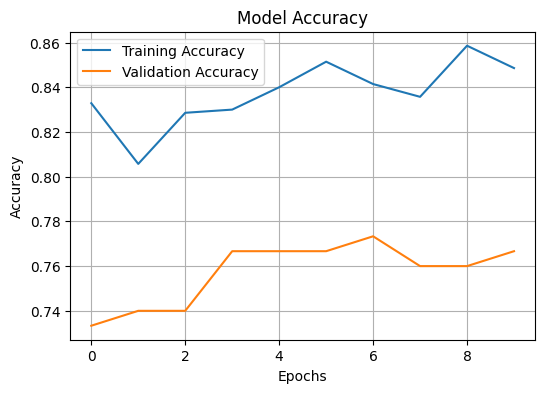

```python
plt.figure(figsize=(6,4))

plt.plot(history1.history['accuracy'],
         label='Training Accuracy')

plt.plot(history1.history['val_accuracy'],
         label='Validation Accuracy')

plt.title('Model Accuracy')

plt.xlabel('Epochs')

plt.ylabel('Accuracy')

plt.legend()

plt.grid(True)

plt.show()
```

Observation:

1. Training accuracy fluctuated slightly but showed an overall improvement during training.
2. Validation accuracy improved gradually from around 73% to 77%.
3. The gap between training and validation accuracy indicates slight overfitting.
4. The model learned important patterns but validation performance remained moderate.
5. Overall, the model achieved acceptable classification performance with scope for further improvement.

### Transfer Learning with VGG16 (Base + FFNN)

Defining the Model

```python
# Load VGG16 base model
base_model = VGG16(
    weights='imagenet',
    include_top=False,
    input_shape=(32,32,3)
)

# Freeze layers
for layer in base_model.layers:
    layer.trainable = False

# Create model
model_ffnn = Sequential()

model_ffnn.add(base_model)

model_ffnn.add(Flatten())

# FFNN Layers
model_ffnn.add(Dense(128, activation='relu'))

model_ffnn.add(Dropout(0.5))

model_ffnn.add(Dense(64, activation='relu'))

model_ffnn.add(Dropout(0.3))

# Output Layer
model_ffnn.add(Dense(1, activation='sigmoid'))

# Model Summary
model_ffnn.summary()
```

```
Model: "sequential_5"
```

```
┏━━━━━━━━━━━━━━━━━━━━━━━━━━━━━━━━━┳━━━━━━━━━━━━━━━━━━━━━━━━┳━━━━━━━━━━━━━━━┓
┃ Layer (type)                    ┃ Output Shape           ┃       Param # ┃
┡━━━━━━━━━━━━━━━━━━━━━━━━━━━━━━━━━╇━━━━━━━━━━━━━━━━━━━━━━━━╇━━━━━━━━━━━━━━━┩
│ vgg16 (Functional)              │ (None, 1, 1, 512)      │    14,714,688 │
├─────────────────────────────────┼────────────────────────┼───────────────┤
│ flatten_5 (Flatten)             │ (None, 512)            │             0 │
├─────────────────────────────────┼────────────────────────┼───────────────┤
│ dense_10 (Dense)                │ (None, 128)            │        65,664 │
├─────────────────────────────────┼────────────────────────┼───────────────┤
│ dropout_2 (Dropout)             │ (None, 128)            │             0 │
├─────────────────────────────────┼────────────────────────┼───────────────┤
│ dense_11 (Dense)                │ (None, 64)             │         8,256 │
├─────────────────────────────────┼────────────────────────┼───────────────┤
│ dropout_3 (Dropout)             │ (None, 64)             │             0 │
├─────────────────────────────────┼────────────────────────┼───────────────┤
│ dense_12 (Dense)                │ (None, 1)              │            65 │
└─────────────────────────────────┴────────────────────────┴───────────────┘
```

```
 Total params: 14,788,673 (56.41 MB)
```

```
 Trainable params: 73,985 (289.00 KB)
```

```
 Non-trainable params: 14,714,688 (56.13 MB)
```

#### Defining Model Configuration

```python
model_ffnn.compile(
    optimizer=Adam(learning_rate=0.0001),
    loss='binary_crossentropy',
    metrics=['accuracy']
)

# Configuration
epochs = 10
batch_size = 5
```

#### Training the Model

```python
history_ffnn = model_ffnn.fit(
    X_train,
    y_train,
    validation_data=(X_val, y_val),
    epochs=epochs,
    batch_size=batch_size
)
```

```
140/140 ━━━━━━━━━━━━━━━━━━━━ 3s 11ms/step - accuracy: 0.5457 - loss: 0.7149 - val_accuracy: 0.7333 - val_loss: 0.6210
140/140 ━━━━━━━━━━━━━━━━━━━━ 1s 9ms/step - accuracy: 0.6429 - loss: 0.6290 - val_accuracy: 0.7133 - val_loss: 0.5763
140/140 ━━━━━━━━━━━━━━━━━━━━ 1s 8ms/step - accuracy: 0.6514 - loss: 0.6216 - val_accuracy: 0.7067 - val_loss: 0.5469
140/140 ━━━━━━━━━━━━━━━━━━━━ 1s 8ms/step - accuracy: 0.6814 - loss: 0.5985 - val_accuracy: 0.7267 - val_loss: 0.5293
140/140 ━━━━━━━━━━━━━━━━━━━━ 1s 8ms/step - accuracy: 0.7243 - loss: 0.5479 - val_accuracy: 0.7200 - val_loss: 0.5143
140/140 ━━━━━━━━━━━━━━━━━━━━ 1s 8ms/step - accuracy: 0.7457 - loss: 0.5264 - val_accuracy: 0.7467 - val_loss: 0.5019
140/140 ━━━━━━━━━━━━━━━━━━━━ 1s 11ms/step - accuracy: 0.7386 - loss: 0.5260 - val_accuracy: 0.7533 - val_loss: 0.4950
140/140 ━━━━━━━━━━━━━━━━━━━━ 1s 10ms/step - accuracy: 0.7643 - loss: 0.5004 - val_accuracy: 0.7667 - val_loss: 0.4851
140/140 ━━━━━━━━━━━━━━━━━━━━ 1s 8ms/step - accuracy: 0.7914 - loss: 0.4879 - val_accuracy: 0.7667 - val_loss: 0.4785
140/140 ━━━━━━━━━━━━━━━━━━━━ 1s 8ms/step - accuracy: 0.7771 - loss: 0.4579 - val_accuracy: 0.7667 - val_loss: 0.4703
```

#### Evaluating Model Performance

```python
# Evaluate Model

loss, accuracy = model_ffnn.evaluate(X_test, y_test)

print("Test Accuracy :", accuracy)

print("Test Loss :", loss)

# Validation Accuracy and Loss

val_loss = history_ffnn.history['val_loss'][-1]

val_accuracy = history_ffnn.history['val_accuracy'][-1]

print("Validation Accuracy :", val_accuracy)

print("Validation Loss :", val_loss)
```

```
5/5 ━━━━━━━━━━━━━━━━━━━━ 0s 17ms/step - accuracy: 0.7867 - loss: 0.4540
Test Accuracy : 0.7866666913032532
Test Loss : 0.45397913455963135
Validation Accuracy : 0.7666666507720947
Validation Loss : 0.4703032374382019
```

# Plotting Training Vs Validation

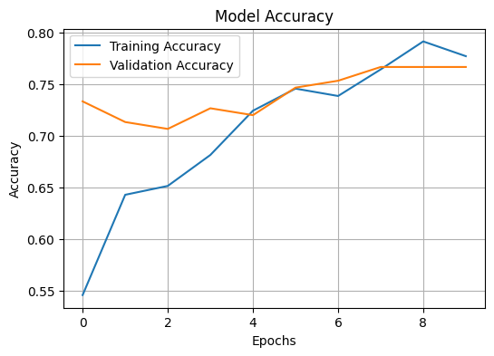

```python
plt.figure(figsize=(6,4))

plt.plot(history_ffnn.history['accuracy'],
         label='Training Accuracy')

plt.plot(history_ffnn.history['val_accuracy'],
         label='Validation Accuracy')

plt.title('Model Accuracy')

plt.xlabel('Epochs')

plt.ylabel('Accuracy')

plt.legend()

plt.grid(True)

plt.show()
```

Observation:

1. Training accuracy increased steadily from around 55% to 79%.
2. Validation accuracy also improved gradually and stabilized around 77%.
3. Both training and validation accuracy followed a similar trend, indicating stable learning.
4. The small difference between training and validation accuracy suggests limited overfitting.
5. Overall, the model showed satisfactory classification performance with moderate accuracy.

### Transfer Learning with VGG16 (Base + FFNN + Data Augmentation)

Defining Data Augmentation

```python
from tensorflow.keras.preprocessing.image import ImageDataGenerator

# Data Augmentation
train_datagen = ImageDataGenerator(
    rotation_range=10,
    zoom_range=0.1,
    horizontal_flip=True
)

# Validation data generator
val_datagen = ImageDataGenerator()

# Generate batches
train_generator = train_datagen.flow(
    X_train,
    y_train,
    batch_size=5
)

val_generator = val_datagen.flow(
    X_val,
    y_val,
    batch_size=5
)
```

#### Defining the Model

```python
# Load VGG16 base model
base_model = VGG16(
    weights='imagenet',
    include_top=False,
    input_shape=(32,32,3)
)

# Freeze layers
for layer in base_model.layers:
    layer.trainable = False

# Create model
model_aug = Sequential()

model_aug.add(base_model)

model_aug.add(Flatten())

# FFNN Layers
model_aug.add(Dense(128, activation='relu'))

model_aug.add(Dropout(0.5))

model_aug.add(Dense(64, activation='relu'))

model_aug.add(Dropout(0.3))

# Output Layer
model_aug.add(Dense(1, activation='sigmoid'))

# Model Summary
model_aug.summary()
```

```
Model: "sequential_6"
```

```
┏━━━━━━━━━━━━━━━━━━━━━━━━━━━━━━━━━┳━━━━━━━━━━━━━━━━━━━━━━━━┳━━━━━━━━━━━━━━━┓
┃ Layer (type)                    ┃ Output Shape           ┃       Param # ┃
┡━━━━━━━━━━━━━━━━━━━━━━━━━━━━━━━━━╇━━━━━━━━━━━━━━━━━━━━━━━━╇━━━━━━━━━━━━━━━┩
│ vgg16 (Functional)              │ (None, 1, 1, 512)      │    14,714,688 │
├─────────────────────────────────┼────────────────────────┼───────────────┤
│ flatten_6 (Flatten)             │ (None, 512)            │             0 │
├─────────────────────────────────┼────────────────────────┼───────────────┤
│ dense_13 (Dense)                │ (None, 128)            │        65,664 │
├─────────────────────────────────┼────────────────────────┼───────────────┤
│ dropout_4 (Dropout)             │ (None, 128)            │             0 │
├─────────────────────────────────┼────────────────────────┼───────────────┤
│ dense_14 (Dense)                │ (None, 64)             │         8,256 │
├─────────────────────────────────┼────────────────────────┼───────────────┤
│ dropout_5 (Dropout)             │ (None, 64)             │             0 │
├─────────────────────────────────┼────────────────────────┼───────────────┤
│ dense_15 (Dense)                │ (None, 1)              │            65 │
└─────────────────────────────────┴────────────────────────┴───────────────┘
```

```
 Total params: 14,788,673 (56.41 MB)
```

```
 Trainable params: 73,985 (289.00 KB)
```

```
 Non-trainable params: 14,714,688 (56.13 MB)
```

#### Defining Model Configuration

```python
model_aug.compile(
    optimizer=Adam(learning_rate=0.0001),
    loss='binary_crossentropy',
    metrics=['accuracy']
)

# Configuration
epochs = 10
batch_size = 5
```

#### Training the Model

```python
history_aug = model_aug.fit(
    train_generator,
    validation_data=val_generator,
    epochs=epochs
)
```

```
140/140 ━━━━━━━━━━━━━━━━━━━━ 4s 17ms/step - accuracy: 0.5400 - loss: 0.7051 - val_accuracy: 0.5933 - val_loss: 0.6617
140/140 ━━━━━━━━━━━━━━━━━━━━ 2s 13ms/step - accuracy: 0.5614 - loss: 0.6941 - val_accuracy: 0.7067 - val_loss: 0.6291
140/140 ━━━━━━━━━━━━━━━━━━━━ 2s 12ms/step - accuracy: 0.6243 - loss: 0.6404 - val_accuracy: 0.7067 - val_loss: 0.5918
140/140 ━━━━━━━━━━━━━━━━━━━━ 2s 12ms/step - accuracy: 0.6800 - loss: 0.6106 - val_accuracy: 0.7600 - val_loss: 0.5641
140/140 ━━━━━━━━━━━━━━━━━━━━ 2s 12ms/step - accuracy: 0.7029 - loss: 0.5818 - val_accuracy: 0.7667 - val_loss: 0.5408
140/140 ━━━━━━━━━━━━━━━━━━━━ 2s 14ms/step - accuracy: 0.7471 - loss: 0.5358 - val_accuracy: 0.7600 - val_loss: 0.5190
140/140 ━━━━━━━━━━━━━━━━━━━━ 2s 16ms/step - accuracy: 0.7586 - loss: 0.5076 - val_accuracy: 0.7733 - val_loss: 0.5005
140/140 ━━━━━━━━━━━━━━━━━━━━ 2s 13ms/step - accuracy: 0.7600 - loss: 0.4930 - val_accuracy: 0.7800 - val_loss: 0.4942
140/140 ━━━━━━━━━━━━━━━━━━━━ 2s 12ms/step - accuracy: 0.7486 - loss: 0.4902 - val_accuracy: 0.7667 - val_loss: 0.4869
140/140 ━━━━━━━━━━━━━━━━━━━━ 2s 12ms/step - accuracy: 0.8014 - loss: 0.4619 - val_accuracy: 0.7600 - val_loss: 0.4832
```

```python
# Convert test data properly
X_test = np.asarray(X_test).astype('float32')

y_test = np.asarray(y_test).astype('float32')

# Flatten labels
y_test = y_test.reshape(len(y_test),)

print(X_test.shape)

print(y_test.shape)
```

```
(150, 32, 32, 3)
(150,)
```

#### Evaluating Model Performance

```python
results = model_aug.evaluate(
    X_test,
    y_test,
    verbose=1
)

# Store values
loss = results[0]

accuracy = results[1]

print("Test Accuracy :", accuracy)

print("Test Loss :", loss)

# Validation metrics
val_accuracy = history_aug.history['val_accuracy'][-1]

val_loss = history_aug.history['val_loss'][-1]

print("Validation Accuracy :", val_accuracy)

print("Validation Loss :", val_loss)
```

```
5/5 ━━━━━━━━━━━━━━━━━━━━ 0s 17ms/step - accuracy: 0.7733 - loss: 0.4594
Test Accuracy : 0.7733333110809326
Test Loss : 0.459402859210968
Validation Accuracy : 0.7599999904632568
Validation Loss : 0.48318731784820557
```

#### Plotting Training Vs Validation Graph

[figure not shown]

```python
plt.figure(figsize=(6,4))

plt.plot(history_aug.history['accuracy'],
         label='Training accuracy')

plt.plot(history_aug.history['val_accuracy'],
         label='Validation accuracy')

plt.title('Training vs Validation Loss')

plt.xlabel('Epochs')

plt.ylabel('Loss')

plt.legend()

plt.grid(True)

plt.show()
```

Observations:

1. Both training and validation accuracy are increasing over epochs — this is expected and good for accuracy.
2. Training accuracy starts low (~0.54) and rises steadily to ~0.80 by epoch 9.
3. Validation accuracy starts higher (~0.60), rises quickly in early epochs, then plateaus around 0.75–0.78.
4. Validation accuracy plateaus earlier (around epoch 3–4) while training accuracy keeps rising.
5. Training accuracy exceeds validation accuracy after epoch 8 — a sign of overfitting beginning.

### Model Performance Comparison

Create Performance Comparison Table

```python
# Store model performance
results = pd.DataFrame({

    'Model': [
        'CNN from Scratch',
        'VGG16 Base',
        'VGG16 + FFNN',
        'VGG16 + FFNN + Data Augmentation'
    ],

    'Accuracy': [
        model.evaluate(X_test, y_test, verbose=0)[1],
        model1.evaluate(X_test, y_test, verbose=0)[1],
        model_ffnn.evaluate(X_test, y_test, verbose=0)[1],
        model_aug.evaluate(X_test, y_test, verbose=0)[1]
    ]

})

# Display results
print(results)
```

[output not shown]

### Visualizing Model Comparison

[figure not shown]

```python
# Plot comparison chart
plt.figure(figsize=(8,5))

plt.bar(results['Model'], results['Accuracy'])

plt.title('Model Performance Comparison')

plt.xlabel('Models')

plt.ylabel('Accuracy')

plt.xticks(rotation=15)

plt.show()
```

### Final Model Selection

```python
# Best model
best_model = results.loc[results['Accuracy'].idxmax()]

print(best_model)
```

[output not shown]

```
1/1 ━━━━━━━━━━━━━━━━━━━━ 0s 68ms/step
```

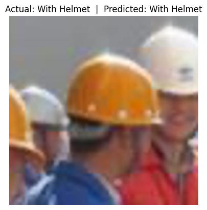

```
Actual   : With Helmet
Predicted: With Helmet
Correct  : True
```

```python
# Pick random image
idx = random.randint(0, len(images) - 1)

# Resize to 32x32 (model expects this)
img = cv2.resize(images[idx], (32, 32))

# Normalize and predict
img = img.astype('float32') / 255.0
img = np.expand_dims(img, axis=0)
prob = model_ffnn.predict(img)[0][0]
pred = 1 if prob >= 0.5 else 0
actual = int(labels.iloc[idx, 0])

# Label names
names = {1: "With Helmet", 0: "Without Helmet"}

# Show original image (200x200)
plt.imshow(images[idx].astype('uint8'))
plt.axis('off')
plt.title(f"Actual: {names[actual]}  |  Predicted: {names[pred]}")
plt.show()

print("Actual   :", names[actual])
print("Predicted:", names[pred])
print("Correct  :", actual == pred)
```